# Clase 5 Modelos

08/09, 2020

## Modelos

## ¿Qué es un modelo?

- Un modelo es una versión simplificada de la realidad que nos permite hacer inferencias o prediccións sobre una población
- Un modelo es un resumen adecuado de la realidad
- Un modelo es una simplificación or aproximación a la realidad y por ende no reflejará toda la realidad (Burnham y Anderson)
- Todos los modelos estan equivocados, algunos son útiles (George Box)

## Veamos un ejemplo

- ¿Cuánto \(CO_2\) captan las plantas?

| Plant | Type | Treatment | conc | uptake |
| --- | --- | --- | --- | --- |
| Qn1 | Quebec | nonchilled | 95 | 16.0 |
| Qn1 | Quebec | nonchilled | 175 | 30.4 |
| Qn1 | Quebec | nonchilled | 250 | 34.8 |
| Qn1 | Quebec | nonchilled | 350 | 37.2 |
| Qn1 | Quebec | nonchilled | 500 | 35.3 |
| Qn1 | Quebec | nonchilled | 675 | 39.2 |
| Qn1 | Quebec | nonchilled | 1000 | 39.7 |
| Qn2 | Quebec | nonchilled | 95 | 13.6 |
| Qn2 | Quebec | nonchilled | 175 | 27.3 |
| Qn2 | Quebec | nonchilled | 250 | 37.1 |
| Qn2 | Quebec | nonchilled | 350 | 41.8 |
| Qn2 | Quebec | nonchilled | 500 | 40.6 |
| Qn2 | Quebec | nonchilled | 675 | 41.4 |
| Qn2 | Quebec | nonchilled | 1000 | 44.3 |
| Qn3 | Quebec | nonchilled | 95 | 16.2 |
| Qn3 | Quebec | nonchilled | 175 | 32.4 |
| Qn3 | Quebec | nonchilled | 250 | 40.3 |
| Qn3 | Quebec | nonchilled | 350 | 42.1 |
| Qn3 | Quebec | nonchilled | 500 | 42.9 |
| Qn3 | Quebec | nonchilled | 675 | 43.9 |
| Qn3 | Quebec | nonchilled | 1000 | 45.5 |
| Qc1 | Quebec | chilled | 95 | 14.2 |
| Qc1 | Quebec | chilled | 175 | 24.1 |
| Qc1 | Quebec | chilled | 250 | 30.3 |
| Qc1 | Quebec | chilled | 350 | 34.6 |
| Qc1 | Quebec | chilled | 500 | 32.5 |
| Qc1 | Quebec | chilled | 675 | 35.4 |
| Qc1 | Quebec | chilled | 1000 | 38.7 |
| Qc2 | Quebec | chilled | 95 | 9.3 |
| Qc2 | Quebec | chilled | 175 | 27.3 |

[output cut: 54 more lines]

## ¿Será la subespecie?

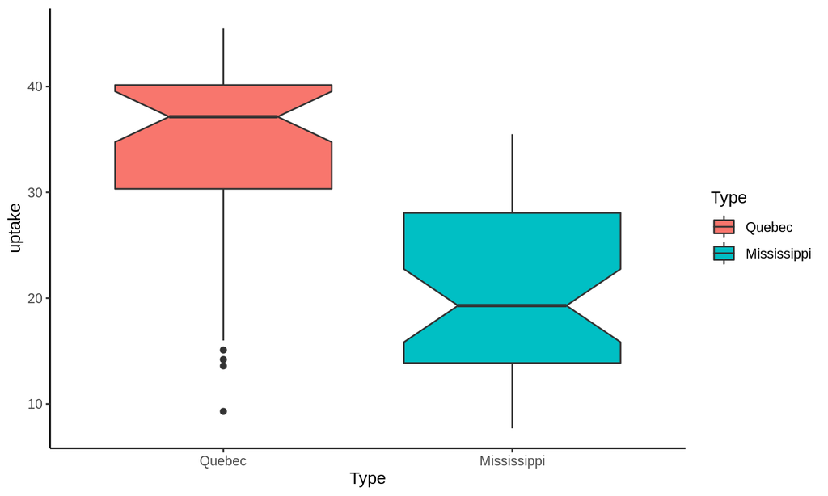

```r
ggplot(CO2, aes(x = Type, y = uptake)) + geom_boxplot(aes(fill = Type),
    notch = TRUE) + theme_classic()
```

## ¿Será el tratamiento?

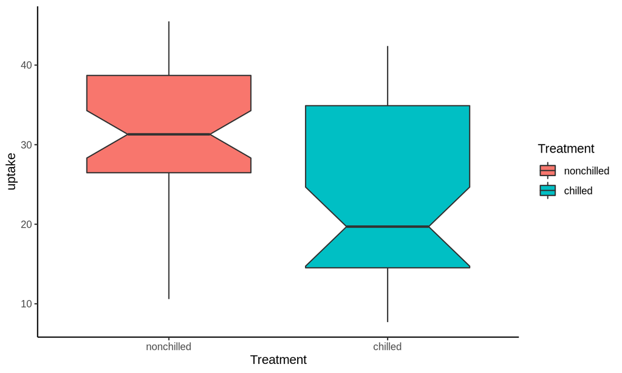

```r
ggplot(CO2, aes(x = Treatment, y = uptake)) + geom_boxplot(aes(fill = Treatment),
    notch = TRUE) + theme_classic()
```

## ¿Será la concentración?

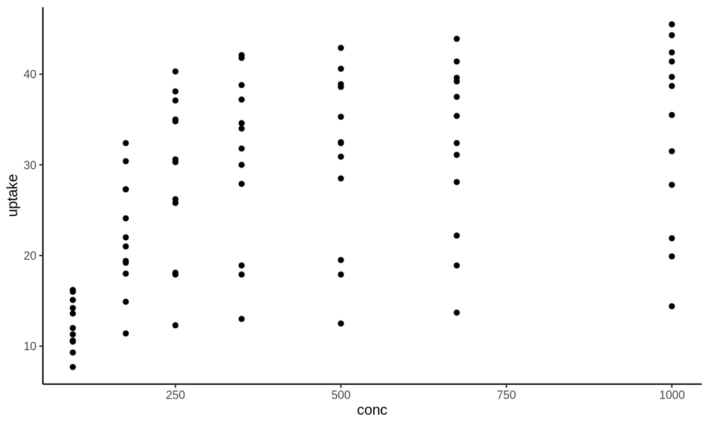

```r
ggplot(CO2, aes(x = conc, y = uptake)) + geom_point() +
    theme_classic()
```

## ¿Como lo determinamos?

## Formula de un modelo

```r
alguna_funcion(Y ~ X1 + X2 + ... + Xn, data = data.frame)
```

- **Y:** Variable respuesta (Captación de \(CO_2\))
- **`~`:** Explicado por
- **\(X_n\):** Variable explicativa n (Subespecie, tratamiento, etc.)
- **data.frame:*** Base de datos (CO2)
- **alguna_funcion:** El modelo a testear (nuestra simplificación de la realidad)

## Algunos modelos en R

| Modelos | Funcion |
| --- | --- |
| Prueba de t | t.test() |
| ANOVA | aov() |
| Modelo lineal simple | lm() |
| modelo lineal generalizado | glm() |
| Modelo aditivo | gam() |
| Modelo no lineal | nls() |
| modelos lineales mixtos | lmer() |
| Boosted regression trees | gbm() |

## ¿Cual usamos para estudiar lo de la planta?

```r
Fit1 <- lm(uptake ~ Type, data = CO2)
```

- Para este ejercicio usaremos un modelo lineal simple
- Equivalente a un ANOVA

## Usando broom para sacarle mas a tu modelo (glance)

- Para ver datos generales del modelo

```r
library(broom)
glance(Fit1)
```

| r.squared | adj.r.squared | sigma | statistic | p.value | df | logLik | AIC | BIC | deviance | df.residual | nobs |
| --- | --- | --- | --- | --- | --- | --- | --- | --- | --- | --- | --- |
| 0.35 | 0.34 | 8.79 | 43.52 | 0 | 1 | -300.8 | 607.6 | 614.89 | 6341.44 | 82 | 84 |

## Usando broom para sacarle mas a tu modelo (tidy)

- Para ver parametros del modelo

```r
tidy(Fit1)
```

| term | estimate | std.error | statistic | p.value |
| --- | --- | --- | --- | --- |
| (Intercept) | 33.54286 | 1.356945 | 24.719384 | 0 |
| TypeMississippi | -12.65952 | 1.919011 | -6.596901 | 0 |

## Usando broom para sacarle mas a tu modelo (augment)

- Para ver predicciones y residuales del modelo

```r
augment(Fit1)
```

| uptake | Type | .fitted | .resid | .std.resid | .hat | .sigma | .cooksd |
| --- | --- | --- | --- | --- | --- | --- | --- |
| 16.0 | Quebec | 33.54286 | -17.5428571 | -2.0190449 | 0.0238095 | 8.625388 | 0.0497139 |
| 30.4 | Quebec | 33.54286 | -3.1428571 | -0.3617181 | 0.0238095 | 8.841068 | 0.0015956 |
| 34.8 | Quebec | 33.54286 | 1.2571429 | 0.1446873 | 0.0238095 | 8.847000 | 0.0002553 |
| 37.2 | Quebec | 33.54286 | 3.6571429 | 0.4209084 | 0.0238095 | 8.838566 | 0.0021605 |
| 35.3 | Quebec | 33.54286 | 1.7571429 | 0.2022333 | 0.0238095 | 8.845923 | 0.0004988 |
| 39.2 | Quebec | 33.54286 | 5.6571429 | 0.6510927 | 0.0238095 | 8.825228 | 0.0051698 |
| 39.7 | Quebec | 33.54286 | 6.1571429 | 0.7086387 | 0.0238095 | 8.820995 | 0.0061240 |
| 13.6 | Quebec | 33.54286 | -19.9428571 | -2.2952661 | 0.0238095 | 8.559179 | 0.0642469 |
| 27.3 | Quebec | 33.54286 | -6.2428571 | -0.7185038 | 0.0238095 | 8.820233 | 0.0062957 |
| 37.1 | Quebec | 33.54286 | 3.5571429 | 0.4093992 | 0.0238095 | 8.839082 | 0.0020440 |
| 41.8 | Quebec | 33.54286 | 8.2571429 | 0.9503322 | 0.0238095 | 8.799269 | 0.0110138 |
| 40.6 | Quebec | 33.54286 | 7.0571429 | 0.8122217 | 0.0238095 | 8.812465 | 0.0080452 |
| 41.4 | Quebec | 33.54286 | 7.8571429 | 0.9042954 | 0.0238095 | 8.803900 | 0.0099726 |
| 44.3 | Quebec | 33.54286 | 10.7571429 | 1.2380626 | 0.0238095 | 8.765042 | 0.0186927 |
| 16.2 | Quebec | 33.54286 | -17.3428571 | -1.9960265 | 0.0238095 | 8.630502 | 0.0485869 |
| 32.4 | Quebec | 33.54286 | -1.1428571 | -0.1315339 | 0.0238095 | 8.847196 | 0.0002110 |
| 40.3 | Quebec | 33.54286 | 6.7571429 | 0.7776940 | 0.0238095 | 8.815439 | 0.0073757 |
| 42.1 | Quebec | 33.54286 | 8.5571429 | 0.9848599 | 0.0238095 | 8.795643 | 0.0118286 |
| 42.9 | Quebec | 33.54286 | 9.3571429 | 1.0769336 | 0.0238095 | 8.785334 | 0.0141437 |
| 43.9 | Quebec | 33.54286 | 10.3571429 | 1.1920257 | 0.0238095 | 8.771133 | 0.0173284 |
| 45.5 | Quebec | 33.54286 | 11.9571429 | 1.3761731 | 0.0238095 | 8.745356 | 0.0230958 |
| 14.2 | Quebec | 33.54286 | -19.3428571 | -2.2262108 | 0.0238095 | 8.576576 | 0.0604392 |
| 24.1 | Quebec | 33.54286 | -9.4428571 | -1.0867986 | 0.0238095 | 8.784174 | 0.0144040 |
| 30.3 | Quebec | 33.54286 | -3.2428571 | -0.3732274 | 0.0238095 | 8.840611 | 0.0016988 |
| 34.6 | Quebec | 33.54286 | 1.0571429 | 0.1216688 | 0.0238095 | 8.847331 | 0.0001805 |
| 32.5 | Quebec | 33.54286 | -1.0428571 | -0.1200247 | 0.0238095 | 8.847352 | 0.0001757 |
| 35.4 | Quebec | 33.54286 | 1.8571429 | 0.2137425 | 0.0238095 | 8.845664 | 0.0005571 |
| 38.7 | Quebec | 33.54286 | 5.1571429 | 0.5935466 | 0.0238095 | 8.829102 | 0.0042963 |
| 9.3 | Quebec | 33.54286 | -24.2428571 | -2.7901623 | 0.0238095 | 8.417641 | 0.0949391 |
| 27.3 | Quebec | 33.54286 | -6.2428571 | -0.7185038 | 0.0238095 | 8.820233 | 0.0062957 |

[output cut: 54 more lines]

## Selección de modelos

- Basado en criterios de información
- Trabajaremos con AIC
- \(K\) número de parámetros
- \(\ln{(\hat{L})}\) ajuste, mas positivo mejor, mas negativo es malo

\[AIC = 2 K - 2 \ln{(\hat{L})}\]

## Modelos candidatos

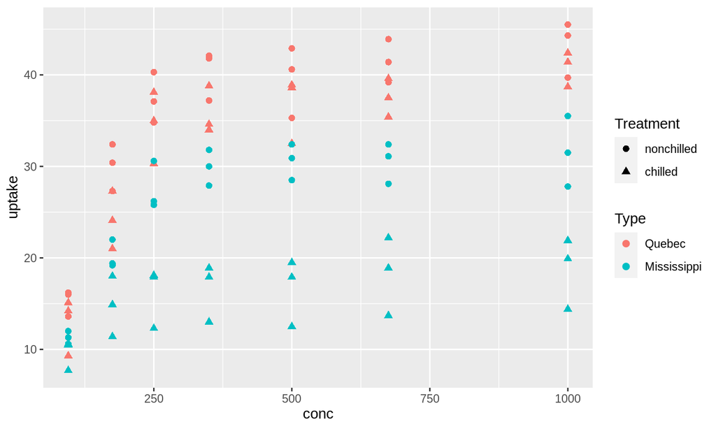

## Modelos candidatos

```r
Fit1 <- lm(uptake ~ Type, data = CO2)
Fit2 <- lm(uptake ~ Treatment, data = CO2)
Fit3 <- lm(uptake ~ conc, data = CO2)
Fit4 <- lm(uptake ~ Type + Treatment + conc, data = CO2)
Fit5 <- lm(uptake ~ Type + conc + I(log(conc)), data = CO2)
```

## Interpretando modelos

## Modelo 1

- uptake ~ Type

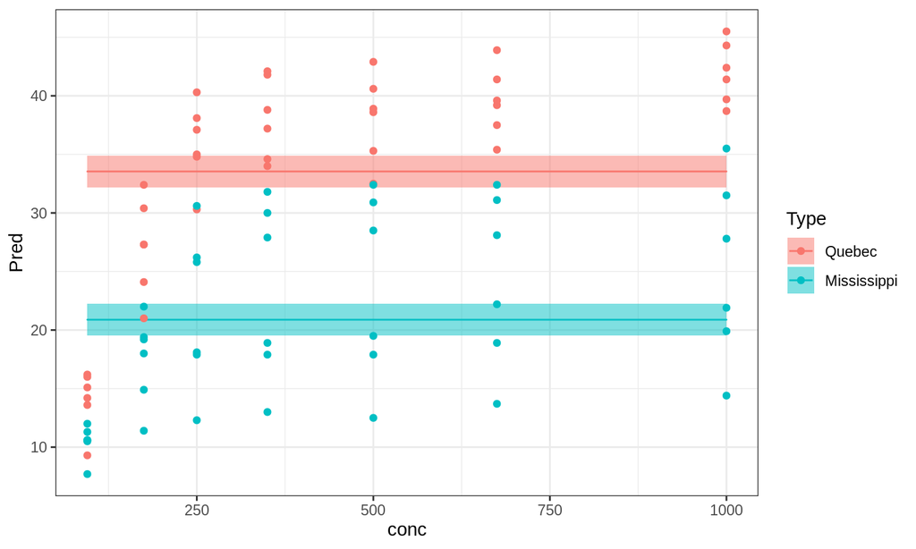

## Modelo 2

- uptake ~ Treatment

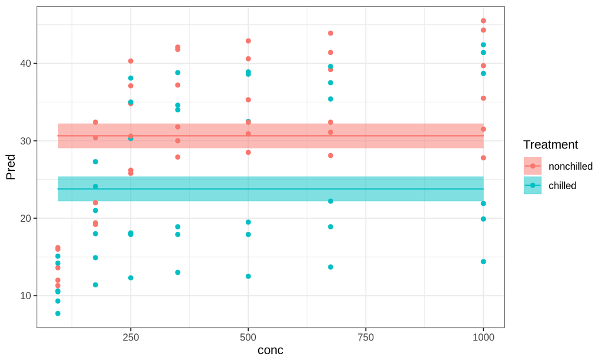

## Modelo 3

- uptake ~ conc

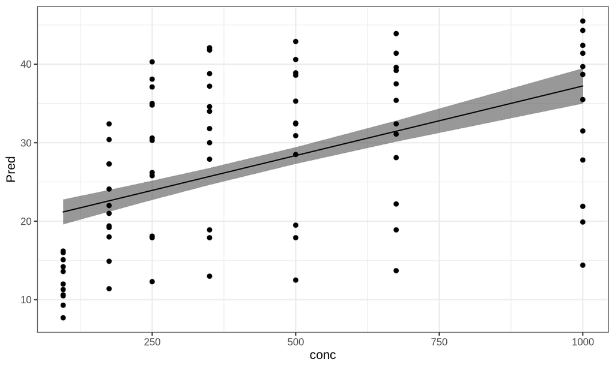

## Modelo 4

- uptake ~ Type + Treatment + conc

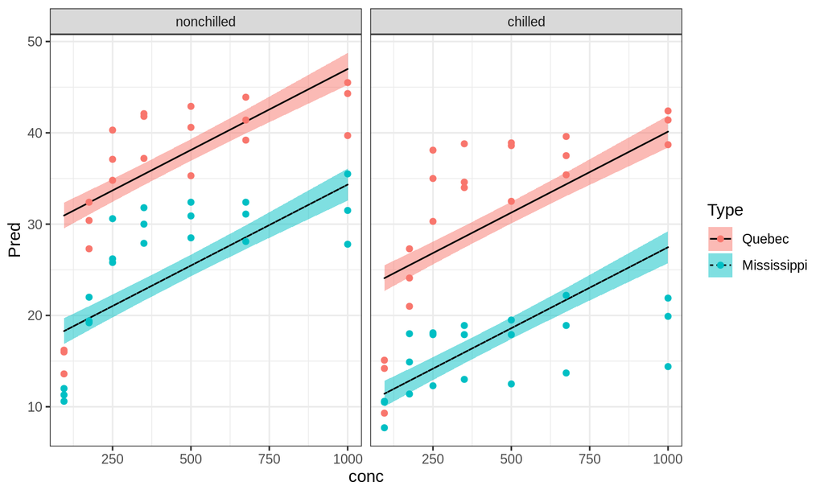

## Modelo 5

- uptake ~ Type + conc + I(log(conc))

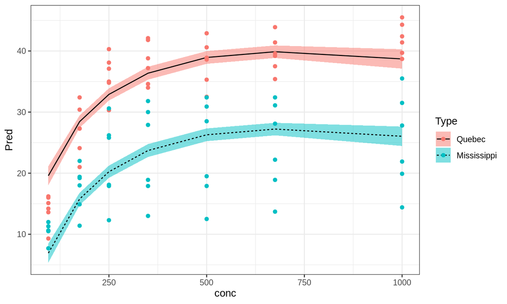

## Seleccion de modelos

## Selección de modelos con broom

```r
Modelo1 <- glance(Fit1) %>% dplyr::select(r.squared,
    AIC) %>% mutate(Modelo = "Fit1")
Modelo2 <- glance(Fit2) %>% dplyr::select(r.squared,
    AIC) %>% mutate(Modelo = "Fit2")
Modelo3 <- glance(Fit3) %>% dplyr::select(r.squared,
    AIC) %>% mutate(Modelo = "Fit3")
Modelo4 <- glance(Fit4) %>% dplyr::select(r.squared,
    AIC) %>% mutate(Modelo = "Fit4")
Modelo5 <- glance(Fit5) %>% dplyr::select(r.squared,
    AIC) %>% mutate(Modelo = "Fit5")

Modelos <- bind_rows(Modelo1, Modelo2, Modelo3, Modelo4,
    Modelo5) %>% arrange(AIC) %>% mutate(DeltaAIC = AIC -
    min(AIC))
```

## Selección de modelos con broom

| r.squared | AIC | Modelo | DeltaAIC |
| --- | --- | --- | --- |
| 0.7488287 | 531.3074 | Fit5 | 0.00000 |
| 0.6839043 | 550.6198 | Fit4 | 19.31241 |
| 0.3467130 | 607.6014 | Fit1 | 76.29403 |
| 0.2353971 | 620.8180 | Fit3 | 89.51059 |
| 0.1017943 | 634.3456 | Fit2 | 103.03817 |

## Extra a ver en el próximo curso

## GLM

## Distribuciones

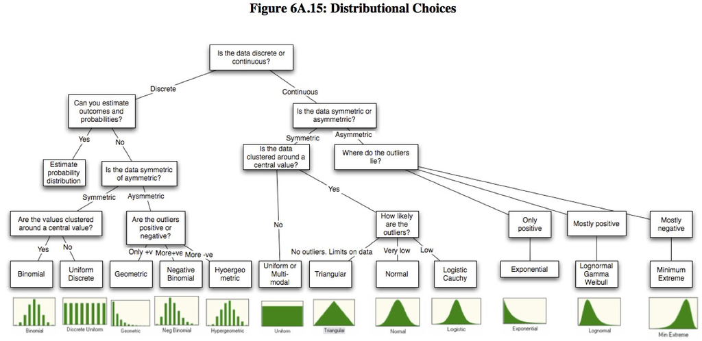

## Estructura de error

- **family =**
- gaussian (variable dependiente continua)
- binomial (variable dependiente 0 o 1)
- poisson (variable dependiente cuentas 1, 2 ,3 ,4 ,5)
- gamma (variable dependiente continua solo positiva)

## Modelo lineal generalizado (familia: binomial)

| Survived | Pclass | Sex | Age | Fare | Cabin | Embarked |
| --- | --- | --- | --- | --- | --- | --- |
| 0 | 3 | male | 22 | 7.2500 | NA | S |
| 1 | 3 | female | 26 | 7.9250 | NA | S |
| 1 | 1 | female | 35 | 53.1000 | C123 | S |
| 0 | 3 | male | 35 | 8.0500 | NA | S |
| 0 | 1 | male | 54 | 51.8625 | E46 | S |
| 0 | 3 | male | 2 | 21.0750 | NA | S |

## Modelo lineal generalizado (familia: binomial)

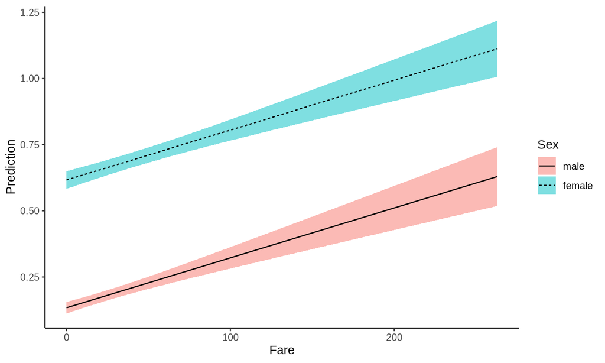

## Modelo lineal generalizado (familia: binomial)

| term | estimate | std.error | statistic | p.value |
| --- | --- | --- | --- | --- |
| (Intercept) | 0.6165752 | 0.0333236 | 18.502645 | 0.00e+00 |
| Fare | 0.0018864 | 0.0004542 | 4.152808 | 3.73e-05 |
| Sexmale | -0.4829290 | 0.0350604 | -13.774197 | 0.00e+00 |

| null.deviance | df.null | logLik | AIC | BIC | deviance | df.residual | nobs |
| --- | --- | --- | --- | --- | --- | --- | --- |
| 143.8804 | 643 | -327.3111 | 662.6221 | 680.4929 | 104.2004 | 641 | 644 |

\(R^2\): 0.3737256

## Modelo lineal generalizado (familia: binomial)

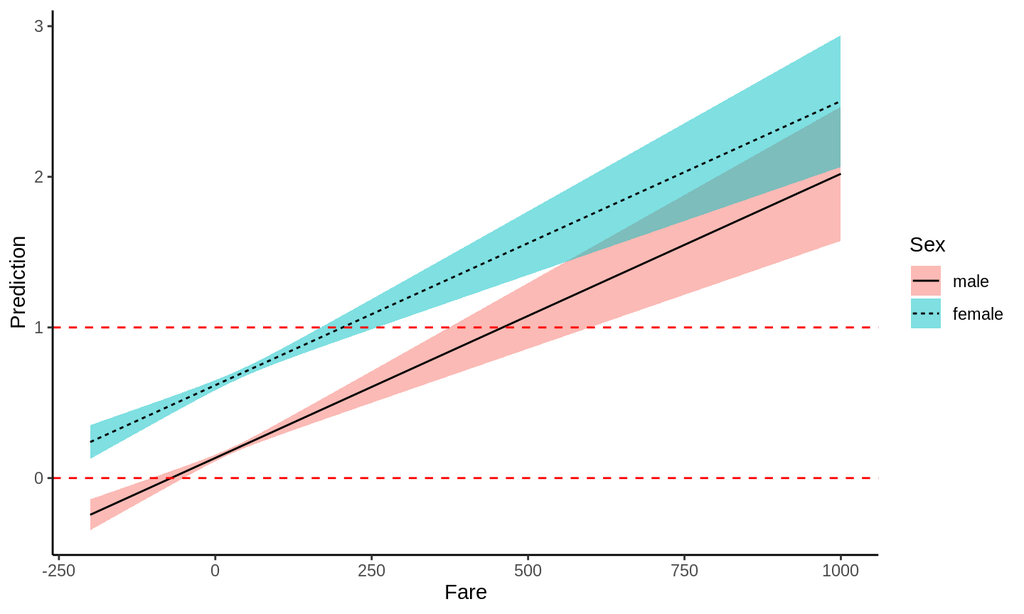

## Modelo lineal generalizado (familia: binomial)

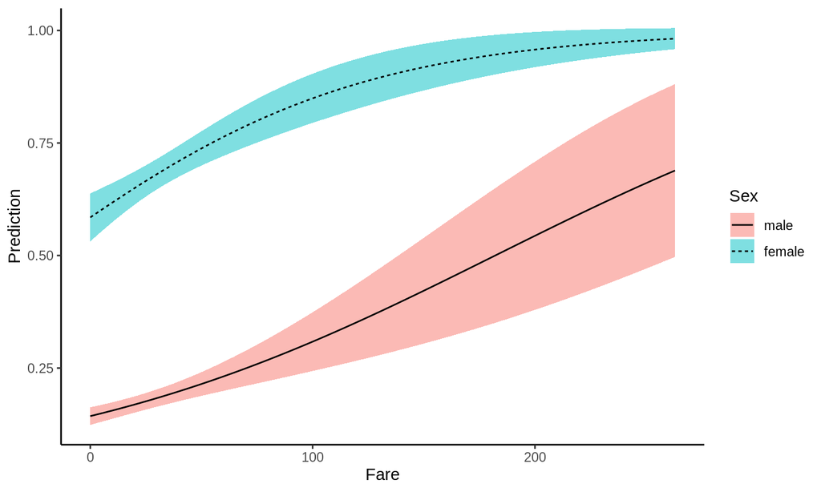

## Modelo lineal generalizado (familia: binomial)

| term | estimate | std.error | statistic | p.value |
| --- | --- | --- | --- | --- |
| (Intercept) | 0.3418628 | 0.2187141 | 1.5630579 | 0.1180390 |
| Fare | 0.0138686 | 0.0055200 | 2.5124456 | 0.0119898 |
| Sexmale | -2.1310117 | 0.2700674 | -7.8906661 | 0.0000000 |
| Fare:Sexmale | -0.0040442 | 0.0066630 | -0.6069597 | 0.5438776 |

| null.deviance | df.null | logLik | AIC | BIC | deviance | df.residual | nobs |
| --- | --- | --- | --- | --- | --- | --- | --- |
| 823.027 | 643 | -321.812 | 651.6239 | 669.4947 | 643.6239 | 640 | 644 |

\(R^2\): 0.3370364

## Modelo lineal generalizado (familia: binomial)

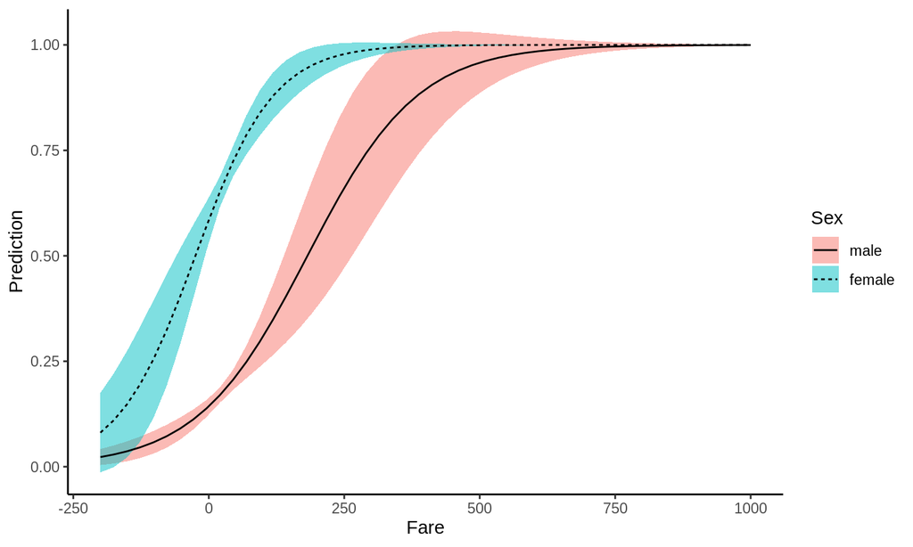

## un ejemplo mas

## Modelos de árboles

```
##     cp  Accuracy     Kappa AccuracySD   KappaSD
## 1 0.00 0.9385473 0.9067089 0.02772756 0.0420216
## 2 0.44 0.7517576 0.6388303 0.16559470 0.2360850
## 3 0.50 0.5069109 0.2934713 0.15528770 0.2089088
```

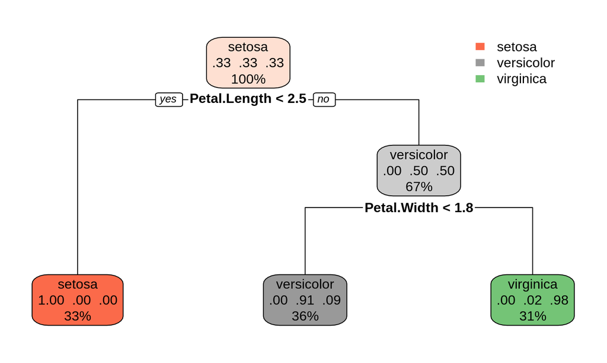

## Para la próxima clase

- Loops normales y con purrr
- Plantillas de Journals para trabajar desde r (Instalar *rticles*)
- Hay que poder knitear a pdf instalar *tinytex*